# Using nls function for nonlinear regression

modeling cell survival curve after radiation

We can use the Poisson distribution to model radiation hit in target cells.
$$P(n)=\frac{\lambda^ne^{-\lambda}}{n!}$$
where $\lambda$ is the average number of events occurred in a unit time and n is the specific number of events occurred in a unit time.

If each “hit” is assumed to result in cell inactivation, then the probability of survival is the probability of not being hit, P(0).
$$P(0)=\frac{\lambda^0e^{-\lambda}}{0!}=e^{-\lambda}$$
We define a dose $D_0$ that delivers, on average, one lethal event per target. This dose will result in $P(0)=e^{-1}=0.37$ survival. $D_0$ is often called the **mean lethal dose**.

#### Linear-Quadratic Model

The *linear-quadratic* (**L-Q**) equation is the most wildly accepted method of fitting the survival of cells following radiation. It is given by
$$S=e^{-(\alpha D+\beta D^{2})}$$
Where S is the number of surviving cells following a dose of D, and $\alpha$ and $\beta$ describe the linear and quadratic parts of the survival curve. The $\alpha$ and $\beta$ constants vary between different tissues and tumors.

#### Multi-Target Model

In a *multi-target* (**M-T**) model, each cell contains n distinct and identical targets and all n targets must be inactivated to kill the cell. The probability that a target is not hit is $e^{-\frac{D}{D_0}}$. The probability that a target is hit is $1-e^{-\frac{D}{D_0}}$. The probability that all n targets are hit is $(1-e^{-\frac{D}{D_0}})^n$. Therefore the probability that all n targets will not be hit, i.e., the probability of survival, is
$$S=1-(1-e^{-\frac{D}{D_0}})^n$$

Here this clonogenic assay shows the survival of FaDu cells following radiation and we are going to fit the dose response curve to the L-Q and M-T models.

Load and view data.

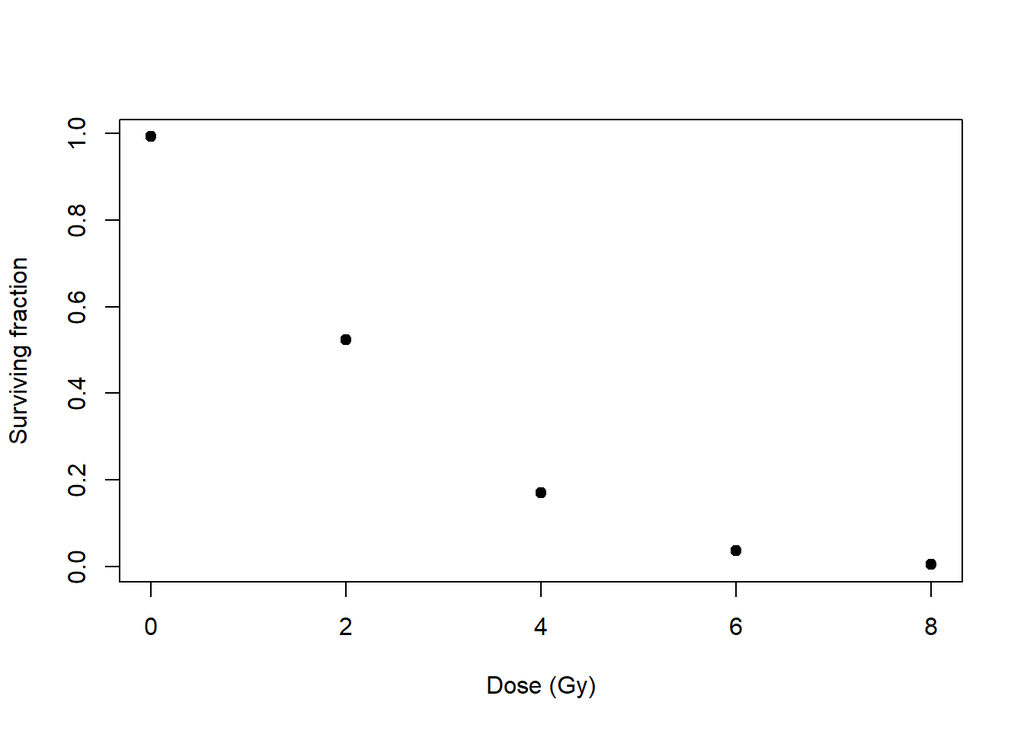

Transforming the L-Q equation to $lnS=-\alpha D-\beta D^2$ reveals that we can use a polynomial regression to get starting estimates.

```r
model_poly <- lm(-log(surviving.fraction)~-1+radiation+I(radiation^2), data=data) #-1 is to set the intercept to 0
summary(model_poly)
```

[output not shown]

```r
model_lq<- nls(surviving.fraction~exp(-a*radiation-b*radiation^2),data=data, start = list(a=coef(model_poly)[1],b=coef(model_poly)[2]))
summary(model_lq)
```

[output not shown]

To fit the M-T model, I don’t have a way of estimating the starting values. Try a few numbers to feed the model.

```r
model_mt <- nls(surviving.fraction ~ 1-(1-exp(-radiation/D0))^n, data=data, start = list(D0=2,n=2))
summary(model_mt)
```

[output not shown]

To create the fitted regression lines

```r
# create more "radiation" points for the fitted line
newdata <- data.frame(radiation = rep(seq(0,8, length = 100),2), model=rep(c("lq","mt"), each=100))

# predict surviving fractions for each radiation dose based on each model
newdata$prediction <- c(predict(model_lq,newdata)[1:100], predict(model_mt,newdata)[1:100])
```

Final plot with ggplot2

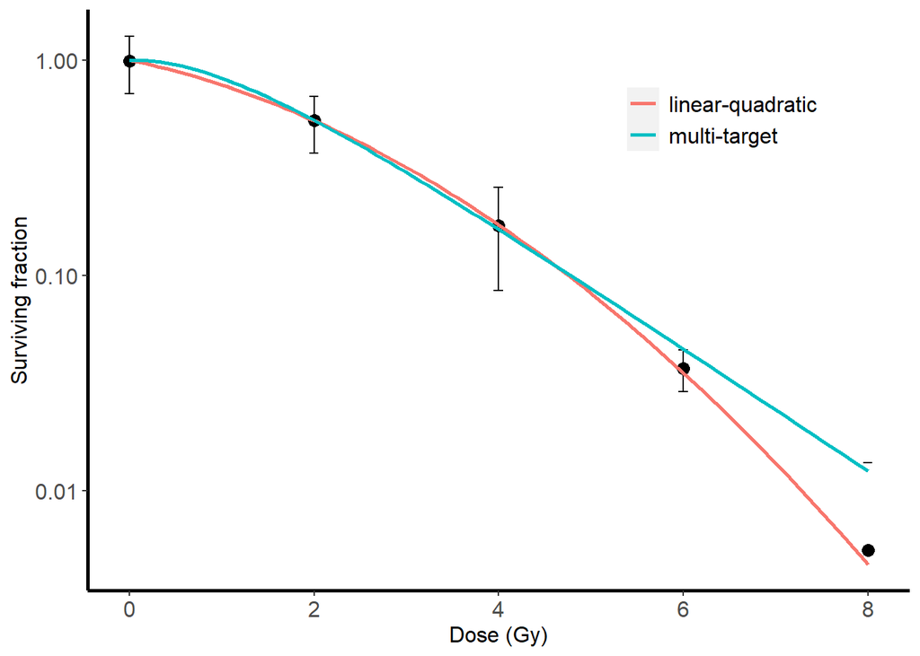

So the FaDu cell line has $\alpha=$ 0.21, $\beta=$ 0.06, $D_0=$ 1.52, and n=2.38.